## Setup

### Load packages

```r
library(ggplot2)
library(dplyr)
```

### Load data

Make sure your data and R Markdown files are in the same directory. When loaded your data file will be called `brfss2013`. Delete this note when before you submit your work.

```r
load("brfss2013.RData")
```

## Part 1: Data

The purpose of this document is to provide information for completion of the data analysis project for week 5 of the “Inferential Statistics” course as part of “Statistics using R” specialization by Duke University offered on Coursera.

Generalizability: Due to data gathering techniques used for collecting the data from the participants of the survey, random sampling techinque can be used and the results can be generalized to the entire population of US

Causality: It was an observational study and no random assignment into groups was done. So, it wont be possible to make any casual inferences

## Part 2: Research questions

**Research quesion 1:** Is there any correlation between the consumption of alcohol (average consumption) and anxiety level for past 30 days and does gender plays any vital role.

**Research quesion 3:** Is there any correlation between number of children at home and a person has exercised in last 30 days? Is it same for both genders?

## Part 3: Exploratory data analysis

NOTE: Insert code chunks as needed by clicking on the “Insert a new code chunk” button (green button with orange arrow) above. Make sure that your code is visible in the project you submit. Delete this note when before you submit your work.

**Research quesion 1:**

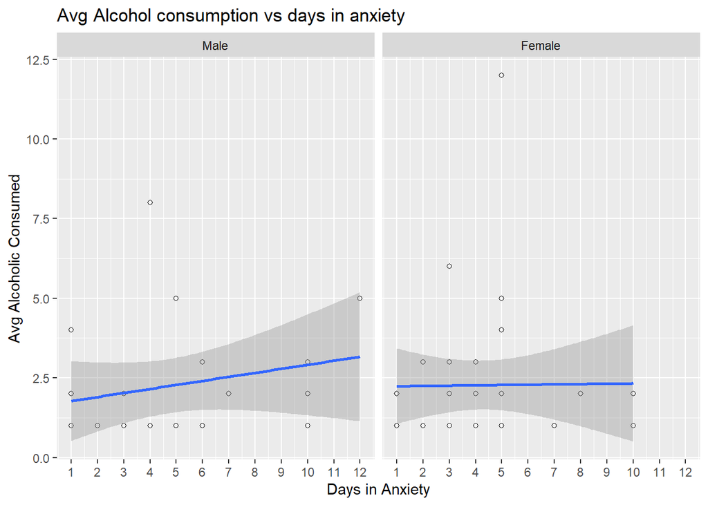

```r
data1 <- select(brfss2013, qlstres2 , sex , avedrnk2) %>%
  filter(!is.na(qlstres2), !is.na(sex), avedrnk2 <= 12 )

# Plot relevant variables

ggplot(data = data1, aes(x = qlstres2, y = avedrnk2 ))+
  geom_point(shape=1) +
  geom_smooth(method=lm)   +
  scale_x_continuous(limits = c(1,12), breaks = 1:12) +
  facet_grid(. ~  sex) +
  ggtitle("Avg Alcohol consumption vs days in anxiety") +
  xlab ("Days in Anxiety") +
  ylab("Avg Alcoholic Consumed")
```